# Human progress and Energy

Declan Oberlies

2026-02-10

## Introduction

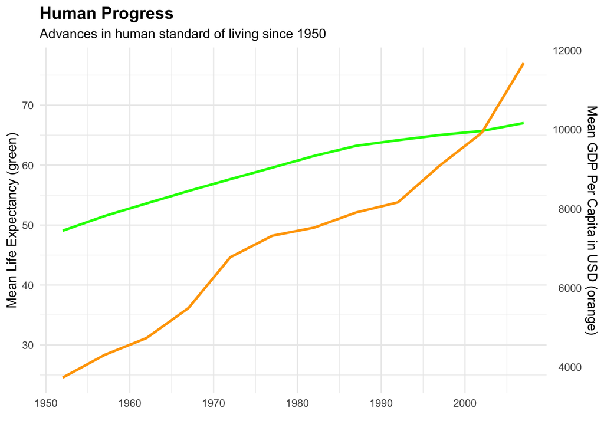

Since 1950, human standard of living has increased drastically. On average, people are living longer and earning more money. This is due to…

- Advances in medicine and healthcare
- Advances in childbirth procedures
- Advanced manufacturing

…and much more. All this advancement and progress has come at a cost.

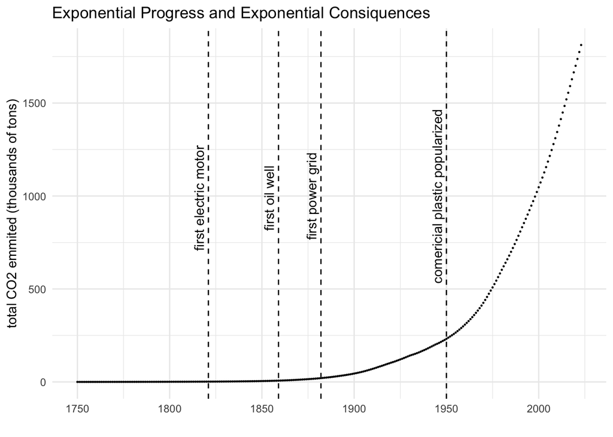

The industry required to fuel our lifestyles emit exponentially more CO<sub>2</sub> every year. CO<sub>2</sub> is a greenhouse gas, and thus an over abundance of it in our atmosphere can create positive feedback loops that threaten to destabilize global ecosystems, and even our agriculture. Many industries emit CO<sub>2</sub>, but the energy industry is by far the largest. As our energy use and carbon emissions increase, we need to be rethink how we produce and consume energy.

## Energy

Civilizations are defined by how they use energy, and human energy use is currently at an all time high. Three nations are particularly high in energy use, namely the USA, China, and India.

[interactive chart not shown]

*black dots represent countries total energy production for a year, lines trace the progression of standout countries*

The USA became a manufacturing superpower in the first half of the 20th century. Since then it has outsourced much of its production, but still has heavy energy demands. China, and more recently India, have also increased their energy production for manufacturing. lets take a look at how there countries produce their energy.

[interactive chart not shown]

*to look at an individual energy source, double click the source in the legend*

From the above graph it is evident that fossil fuels, especially coal, are the most common fuel sources for power plants. Coal is useful because it is abundant and cheep, however it releases more CO<sub>2</sub> than any of the other fuels.

[interactive chart not shown]

Fortunately, green energy sources like wind turbines and photovoltaics are becoming less and less expensive. As green energy prices continue to decrease, it becomes possible to replace old coal burning power plants with renewable energy sources. This will be critical because…

1. decreased greenhouse gas emissions
2. energy diversity and independence

With resent global conflicts like the Ukraine war and the Iran war, global energy supply lines were disrupted and caused economic problems in countries that had no part in the war. If these countries were able to switch to green renewable energy sources, these energy supply line disruptions wouldn’t be an issue. The use of renewable sources forces nations to diversify energy production which makes it more stable.

By switching to cheaper renewable energy sources, we can protect our economies from global disruptions, prevent environmental catastrophe cause by climate change, and still prosper in our high energy lifestyle.